# Bank Marketing Campaign Success Predictor

jrfoster  
20 February, 2017

### Background

Marketing in banks faces some significant challenges

- Regaing customer trust in light of reputation damage done in the last few years
- Erosion of customer satisfaction and loyalty: no more customers for life
- Difficulties going digital due to level of planning and compliance

Embracing analytics and tailoring campaigns based on facts can help!

### Campaign Success Predictor Application

This concept application uses the [Bank Marketing Dataset](https://archive.ics.uci.edu/ml/datasets/Bank+Marketing) to do the following

- Create a predictive model of success based on current customers and past experience
- Allow different users to accomplish different goals
  - Marketing managers can see what works for their customer base and what doesn't
  - Telephone marketers can tailor approach based on customer

### Prediction Model Overview

- Gradient Boosting Machine model based on five variables
  - 10-fold Cross Validation
- Feature extraction based on several methods
  - Principal Component Analysis
  - Best First
  - Forward Search
  - Information Gain

```r
load("./BankMarketing/gbmModel.RData")
test <- readRDS("TestingData.rds")
pred <- predict(gbmModel, test)
conf <- confusionMatrix(test$y, pred)
acc <- unname(conf$overall[1])
oosEror <- 1- acc
kappa <- unname(conf$overall[2])
trAcc <- unname(gbmModel$results$Accuracy)
table <- data.frame(acc, oosEror, kappa, trAcc)
kable(table, digits=5, col.names=c("Testing Accuracy", "Out-Of-Sample Error", "Kappa", "Training Accuracy"))
```

| Testing Accuracy | Out-Of-Sample Error | Kappa | Training Accuracy |
| --- | --- | --- | --- |
| 0.89441 | 0.10559 | 0.25891 | 0.89203 |

### Application Screen Shot

The image below provides a glimpse at the application

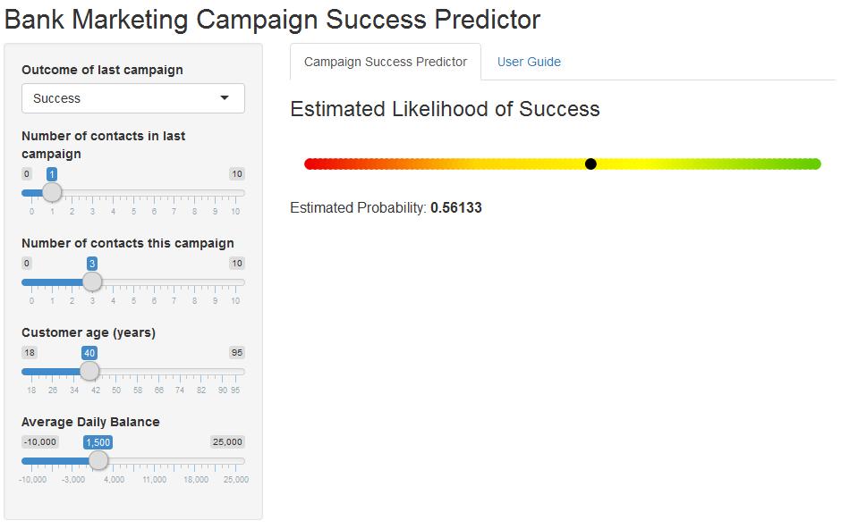

### Conclusion

An application of this nature could have the following benefits

- It could help a person performing telephone marketing to adapt their approach
- It could help a marketing manager tailor a campaign based on known information

If you're ready to give it a try

- [ShinyApps.io](https://jrfoster.shinyapps.io/BankMarketing/) deployment of the application

If you want to see some code

- [GitHub](https://github.com/jrfoster/ddpProject) repo containing code for this presentation and the application itself